# (Fordgobike Data Exploration )

## by (Mohamed Hossam El_Din)

## Preliminary Wrangling

> This Dataset from February 2019 contains data about bike sharing system trips including the duration, start and end times and locations, riders' birth years and genders, whether they are customers or subscribers, and whether they are inrolled in bike_share_for_all program or not.

```python
# import all packages and set plots to be embedded inline
import numpy as np
import pandas as pd
import matplotlib.pyplot as plt
import seaborn as sb

%matplotlib inline
```

```python
# Loading the data into (fordgobike) dataframe:
fordgobike = pd.read_csv('201902-fordgobike-tripdata.csv')
fordgobike.head()
```

|  | duration_sec | start_time | end_time | start_station_id | start_station_name | start_station_latitude | start_station_longitude | end_station_id | end_station_name | end_station_latitude | end_station_longitude | bike_id | user_type | member_birth_year | member_gender | bike_share_for_all_trip |
| --- | --- | --- | --- | --- | --- | --- | --- | --- | --- | --- | --- | --- | --- | --- | --- | --- |
| 0 | 52185 | 2019-02-28 17:32:10.1450 | 2019-03-01 08:01:55.9750 | 21.0 | Montgomery St BART Station (Market St at 2nd St) | 37.789625 | -122.400811 | 13.0 | Commercial St at Montgomery St | 37.794231 | -122.402923 | 4902 | Customer | 1984.0 | Male | No |
| 1 | 42521 | 2019-02-28 18:53:21.7890 | 2019-03-01 06:42:03.0560 | 23.0 | The Embarcadero at Steuart St | 37.791464 | -122.391034 | 81.0 | Berry St at 4th St | 37.775880 | -122.393170 | 2535 | Customer | NaN | NaN | No |
| 2 | 61854 | 2019-02-28 12:13:13.2180 | 2019-03-01 05:24:08.1460 | 86.0 | Market St at Dolores St | 37.769305 | -122.426826 | 3.0 | Powell St BART Station (Market St at 4th St) | 37.786375 | -122.404904 | 5905 | Customer | 1972.0 | Male | No |
| 3 | 36490 | 2019-02-28 17:54:26.0100 | 2019-03-01 04:02:36.8420 | 375.0 | Grove St at Masonic Ave | 37.774836 | -122.446546 | 70.0 | Central Ave at Fell St | 37.773311 | -122.444293 | 6638 | Subscriber | 1989.0 | Other | No |
| 4 | 1585 | 2019-02-28 23:54:18.5490 | 2019-03-01 00:20:44.0740 | 7.0 | Frank H Ogawa Plaza | 37.804562 | -122.271738 | 222.0 | 10th Ave at E 15th St | 37.792714 | -122.248780 | 4898 | Subscriber | 1974.0 | Male | Yes |

Most of these columns will not be useful for my invistigation so I will drop them in a few steps.

```python
print(fordgobike.shape)
```

```
(183412, 16)
```

```python
# General overview:
fordgobike.info()
```

```
<class 'pandas.core.frame.DataFrame'>
RangeIndex: 183412 entries, 0 to 183411
Data columns (total 16 columns):
 #   Column                   Non-Null Count   Dtype
---  ------                   --------------   -----
 0   duration_sec             183412 non-null  int64
 1   start_time               183412 non-null  object
 2   end_time                 183412 non-null  object
 3   start_station_id         183215 non-null  float64
 4   start_station_name       183215 non-null  object
 5   start_station_latitude   183412 non-null  float64
 6   start_station_longitude  183412 non-null  float64
 7   end_station_id           183215 non-null  float64
 8   end_station_name         183215 non-null  object
 9   end_station_latitude     183412 non-null  float64
 10  end_station_longitude    183412 non-null  float64
 11  bike_id                  183412 non-null  int64
 12  user_type                183412 non-null  object
 13  member_birth_year        175147 non-null  float64
 14  member_gender            175147 non-null  object
 15  bike_share_for_all_trip  183412 non-null  object
dtypes: float64(7), int64(2), object(7)
memory usage: 22.4+ MB
```

```python
fordgobike.duration_sec.describe()
```

```
count    183412.000000
mean        726.078435
std        1794.389780
min          61.000000
25%         325.000000
50%         514.000000
75%         796.000000
max       85444.000000
Name: duration_sec, dtype: float64
```

```python
sum(fordgobike.duplicated())
```

```
0
```

No duplicates.

So far I will need to add columns for:

```
-duration in minutes to make it more interpretable during invistigation: duration_min
-the day of the month from start_time column since the data is for February 2019 : start_day
-the hour of the day from start_time column : start_hour
-the day of week : weekDay
-the age form member_birth_year since it will be more useful and easier to interpret.
```

```python
# For duration, I going to change it to be in minutes rather than seconds, so that it's more interpretable.

duration_min = fordgobike.duration_sec / 60
fordgobike.insert(1, 'duration_min', duration_min)
fordgobike['duration_min'] = fordgobike['duration_min'].round(decimals=0)
fordgobike.duration_min = fordgobike.duration_min.astype(int)
```

```python
# now extracting start_day, and start_hour form start_time column:

fordgobike.start_time = pd.to_datetime(fordgobike.start_time)

start_day = fordgobike.start_time.dt.day
fordgobike.insert(3, 'start_day', start_day)

start_hour = fordgobike.start_time.dt.hour
fordgobike.insert(3, 'start_hour', start_hour)
```

```python
# Here, I'm creating a column for Day names so that I can track the relation between them and the trip duration.

days={0:'Monday', 1:'Tuesday', 2:'Wednesday', 3:'Thursday', 4:'Friday', 5:'Saturday', 6:'Sunday'}
weekDay = fordgobike['start_time'].dt.dayofweek.map(days)
fordgobike.insert(5, 'weekDay', weekDay)
```

```python
# changing the weekDay column into categorical ordinal:

days = ['Monday', 'Tuesday', 'Wednesday', 'Thursday', 'Friday', 'Saturday', 'Sunday']
week_days = pd.api.types.CategoricalDtype(ordered=True, categories=days)
fordgobike.weekDay = fordgobike.weekDay.astype(week_days)
```

```python
# Since I want to make use of age, gender, and user type, I will drop any row having NaN value in these columns.

fordgobike.dropna(subset=['user_type', 'member_birth_year', 'member_gender', 'bike_share_for_all_trip'], inplace=True)
```

```python
# Creating a column "age" for riders' ages instead of their birth years:

fordgobike.member_birth_year = fordgobike.member_birth_year.astype(int)
fordgobike['age'] = 2019 - fordgobike.member_birth_year
```

```python
# Dropping unwanted columns:

fordgobike.drop(labels=['duration_sec', 'start_time', 'end_time', 'start_station_id', 'start_station_name', 'start_station_latitude', 'start_station_longitude',
                       'end_station_id', 'end_station_name', 'end_station_latitude', 'end_station_longitude', 'bike_id',
                        'member_birth_year'], axis=1, inplace=True)
```

```python
# This is how my dataframe looks like after wrangling:

fordgobike.reset_index(inplace=True, drop=True)
fordgobike.head()
```

|  | duration_min | start_hour | start_day | weekDay | user_type | member_gender | bike_share_for_all_trip | age |
| --- | --- | --- | --- | --- | --- | --- | --- | --- |
| 0 | 870 | 17 | 28 | Thursday | Customer | Male | No | 35 |
| 1 | 1031 | 12 | 28 | Thursday | Customer | Male | No | 47 |
| 2 | 608 | 17 | 28 | Thursday | Subscriber | Other | No | 30 |
| 3 | 26 | 23 | 28 | Thursday | Subscriber | Male | Yes | 45 |
| 4 | 30 | 23 | 28 | Thursday | Subscriber | Male | No | 60 |

```python
print(fordgobike.shape)
print(fordgobike.dtypes)
```

```
(175147, 8)
duration_min                  int32
start_hour                    int64
start_day                     int64
weekDay                    category
user_type                    object
member_gender                object
bike_share_for_all_trip      object
age                           int32
dtype: object
```

### What is/are the main feature(s) of interest in your dataset?

> I want to see what variables have the most effect on the duration of each trip. So (duration_min) is my main feature.

### What features in the dataset do you think will help support your investigation into your feature(s) of interest?

> I think that a trip duration will change from hour to hour within the day(start_hour), from day to day within a month(start_day), for each day in the week(weekDay). Also (user_type, gender, and age) my have a relation with the average trip duration.

## Univariate Exploration

##### I will be investigating :

```
1-the distibution of the duration.
2-the distibution of the start_hour.
3-the distibution of the start_day, and weekDay.
4-the distibution of the age.
5-the relative fractions of user_type, member_gender, and bike_share_for_all_trip.
```

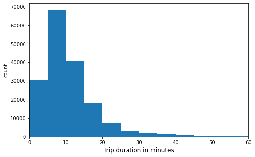

```python
# 1-the distibution of the duration:

bins = np.arange(0, fordgobike.duration_min.max()+5, 5)

plt.figure(figsize=[8, 5])
plt.hist(data=fordgobike, x='duration_min', bins=bins);
plt.xlim(0, 60)
plt.xlabel('Trip duration in minutes', fontsize=12)
plt.ylabel('count');
```

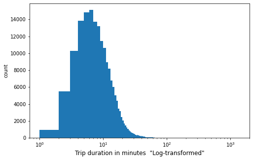

```python
# Transforming to log scale:
bins = np.arange(0, fordgobike.duration_min.max()+1, 1)

plt.figure(figsize=[8, 5])
plt.hist(data=fordgobike, x='duration_min', bins=bins)
plt.xscale('log')
plt.xlabel('Trip duration in minutes  "Log-transformed"', fontsize=12)
plt.ylabel('count');
```

As we can see the duration distribution is unimodal with the peak at around 6 minutes.

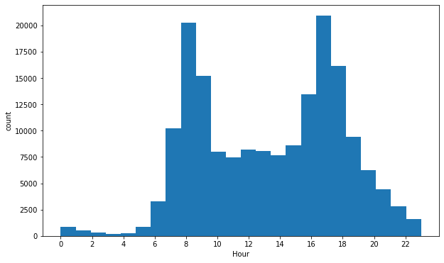

```python
# 2-the distibution of the start_hour:

plt.figure(figsize=[10,6])
plt.hist(data=fordgobike, x='start_hour', bins=24)
plt.xticks(np.arange(0,24,2), np.arange(0,24,2));
plt.xlabel('Hour')
plt.ylabel('count');
```

The distibution is bimodal with two peaks at about (8 am) and (5 pm) which are the times for going to and retuning from a university or work and also the rush hours for traffic where people may use bikes instead of vehicels.

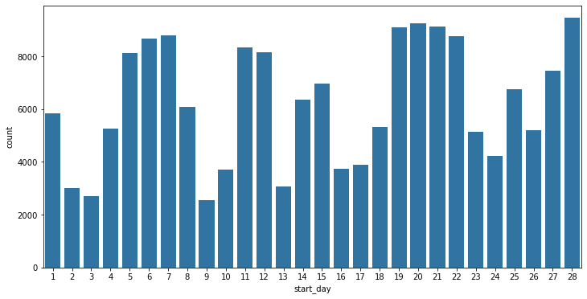

```python
# 3-the distibution of the start_day:

default_color = sb.color_palette()[0]
default_color_1 = sb.color_palette()[1]
default_color_2 = sb.color_palette()[2]
default_color_3 = sb.color_palette()[3]

plt.figure(figsize=[12,6])

sb.countplot(data=fordgobike, x='start_day', color=default_color);
```

As one would expect, there is almost a steady number of trips for all days of the month separated by two days between each five days when people mostly are in weekend (2,3 low trips) then (4:8 high) then (9,10 low) and so on, though the pattern is not normal for the 13th of the month. It may be a holiday or has something to do with Valentine's Day.

```python
# what is that day?
fordgobike[fordgobike.start_day == 13].weekDay.value_counts()
```

```
Wednesday    3080
Sunday          0
Saturday        0
Friday          0
Thursday        0
Tuesday         0
Monday          0
Name: weekDay, dtype: int64
```

"Wednesday", it is not a weekend so it should have a normal number of trips like the day before it for example. It may need farther invistigation.

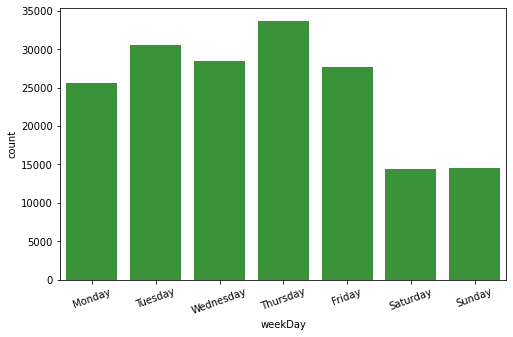

```python
# now plotting a bar chart for week days to see the distribution:

plt.figure(figsize=[8, 5])
sb.countplot(data=fordgobike, x='weekDay', color=default_color_2)
plt.xticks(rotation=20);
```

As we expected, weekends have lower number of trips.

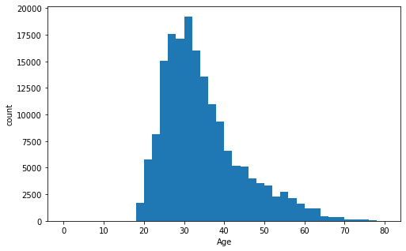

```python
# 4-the distibution of the age:

plt.figure(figsize=[8, 5])
bins = np.arange(0, fordgobike.age.max()+2, 2)
plt.hist(data=fordgobike, x='age', bins=bins)
plt.xlabel('Age')
plt.ylabel('count');
```

The majority are between 20 and 60, which is the expected category to ride a bike including university students and workers, however, there is also a significant fraction of relatively old people who ride bikes. There are some outliers in the age so I think I will exclude the trips with ages greater than 80.

```python
# looking at the number of outliers
fordgobike[fordgobike.age > 80].shape
```

```
(192, 8)
```

```python
# excluding outliers from the data:
fordgobike.drop(fordgobike[fordgobike.age > 80].index, axis=0, inplace=True)
fordgobike.reset_index(inplace=True, drop=True)
```

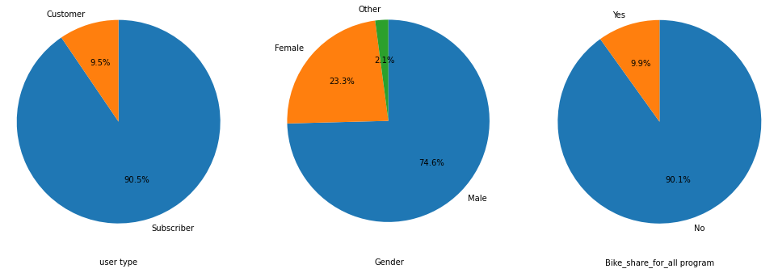

```python
# 5-the relative fractions of user_type, member_gender, and bike_share_for_all_trip:

plt.figure(figsize=[17,8])

plt.subplot(1,3,1)
sorted_counts = fordgobike.user_type.value_counts()
plt.pie(x=sorted_counts, labels=sorted_counts.index, startangle=90, counterclock=False,
        autopct=lambda p: '{:.1f}%'.format(p))
plt.axis('square')
plt.xlabel('user type', labelpad=30);

plt.subplot(1,3,2)
sorted_counts = fordgobike.member_gender.value_counts()
plt.pie(x=sorted_counts, labels=sorted_counts.index, startangle=90, counterclock=False,
        autopct=lambda p: '{:.1f}%'.format(p))
plt.axis('square');
plt.xlabel('Gender', labelpad=30);

plt.subplot(1,3,3)
sorted_counts = fordgobike.bike_share_for_all_trip.value_counts()
plt.pie(x=sorted_counts, labels=sorted_counts.index, startangle=90, counterclock=False,
        autopct=lambda p: '{:.1f}%'.format(p))
plt.axis('square');
plt.xlabel('Bike_share_for_all program', labelpad=30);
```

Most of the trips are for male subscribers who are not part of Bike_share_for_all program.

### Discuss the distribution(s) of your variable(s) of interest. Were there any unusual points? Did you need to perform any transformations?

> The duration variable distribution was highly right-skewed with a long tail of data, so I used a log scale for the distribution and it appeared unimodal with the peak at around 6 minutes.

### Of the features you investigated, were there any unusual distributions? Did you perform any operations on the data to tidy, adjust, or change the form of the data? If so, why did you do this?

> For the start_day distribution, there was an abnormal value associated with 13th of the month. Regarding rider ages, there were outliers, so I excluded all the data with age values greater than 80 years since we expect bike riders to be relatively young. Also, there were only 192 outliers, which is not a significant fraction.

## Bivariate Exploration

I will consider the relation between each of the brevious features(start_hour, weekDay, member_gender, user_type and age) and the average of trip duration.

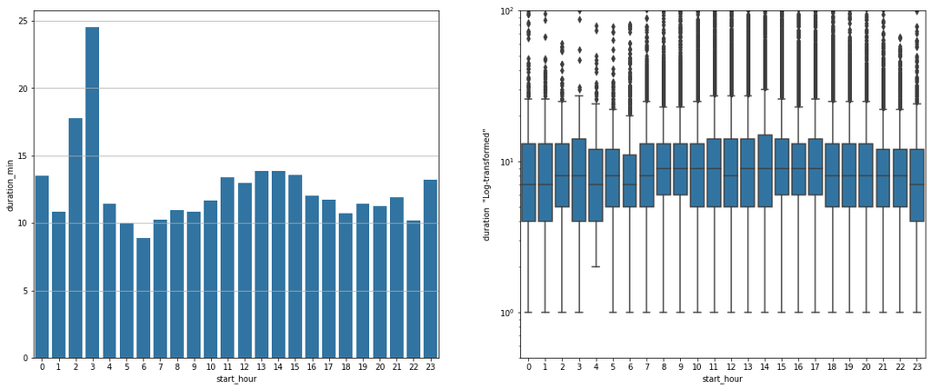

```python
# Frist How the duration is affected by the time of the day:

plt.figure(figsize=[20,8])

plt.subplot(1,2,1)
sb.barplot(data=fordgobike, x='start_hour', y='duration_min', color=default_color, ci=0)
plt.grid(axis='y');

plt.subplot(1,2,2)
sb.boxplot(data=fordgobike, x='start_hour', y='duration_min', color=default_color);
plt.yscale('log')
plt.ylabel('duration  "Log-transformed"', labelpad=10)
plt.ylim(0.5,100);
```

Most of the trips take, on average, from 4 to 11 minutes. Looking at the right plot, we can see that the average duration rises a little bit at the noon of the day. However, the interesting thing is the peak at 2 and 3 am. One can expain that by darkness of the streets at this time since many shops will be closed already.

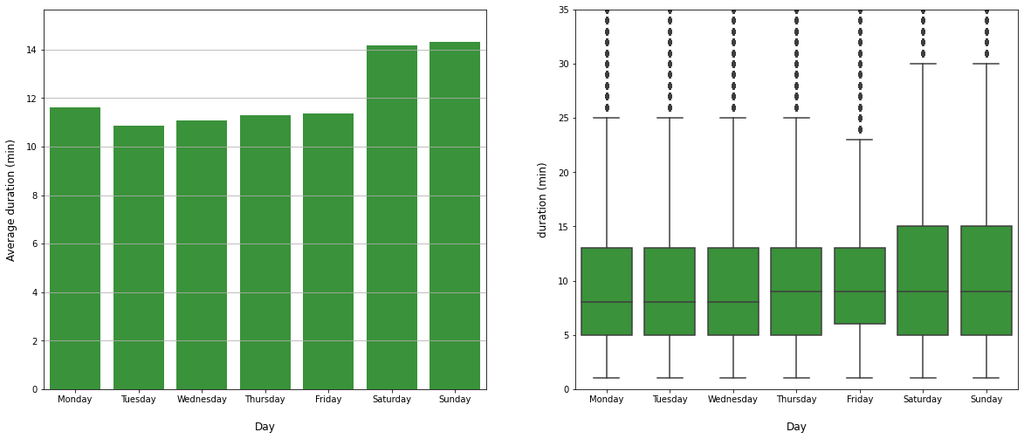

```python
# Now, I will plot the average duration for each day:

plt.figure(figsize=[20,8])

plt.subplot(1,2,1)
sb.barplot(data=fordgobike, x='weekDay', y='duration_min', color=default_color_2, errwidth=0)
plt.grid(axis='y')
plt.xlabel('Day', fontsize=12, labelpad=20)
plt.ylabel('Average duration (min)', fontsize=12, labelpad=10);

plt.subplot(1,2,2)
sb.boxplot(data=fordgobike, x='weekDay', y='duration_min', color=default_color_2)
plt.ylim(0, 35)
plt.xlabel('Day', fontsize=12, labelpad=20)
plt.ylabel('duration (min)', fontsize=12, labelpad=10);
```

The mean duration is nearly steady, of about 11 minutes, through week days. However, the average duration for weekends is a little bit longer. I will do further invistigation on that by faceting.

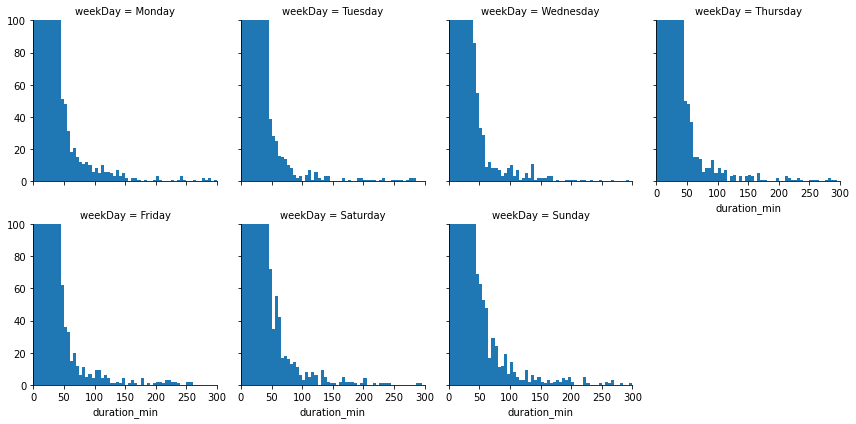

```python
# faceting:
bins = np.arange(0, fordgobike.duration_min.max()+5, 5)
g = sb.FacetGrid(data=fordgobike, col='weekDay', col_wrap=4, xlim=(0,300), ylim=(0,100))
g.map(plt.hist, 'duration_min', bins=bins);
```

As we can see, they all have almost fair distribution for high durations. Taking into account the fact that there are smaller number of trips on weekends (saturday, sunday), the distribution for high durations should affect the average. That's why the average duration for weekends is a little bit longer than that for weekdays.

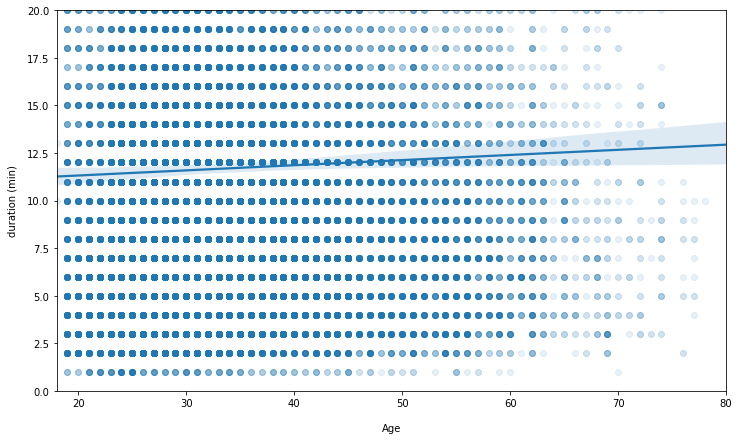

```python
# Now looking if there is any relation between age and trip duration:

np.random.seed(2019)
samples = np.random.choice(fordgobike.shape[0], 50000, replace = False)
ford_samp = fordgobike.loc[samples,:]

plt.figure(figsize=[12,7])
sb.regplot(data=ford_samp, x='age', y='duration_min', scatter_kws={'alpha':.1})
plt.ylim(0,20)
plt.xlabel('Age', labelpad=15)
plt.ylabel('duration (min)', labelpad=10);
```

Despite that most of data is at to lower ages, there is obviously a very weak positive correlation between the age and duration.

```python
# Finding the correlation between age and duration:
fordgobike[['duration_min', 'age']].corr().round(decimals=2)
```

|  | duration_min | age |
| --- | --- | --- |
| duration_min | 1.00 | 0.01 |
| age | 0.01 | 1.00 |

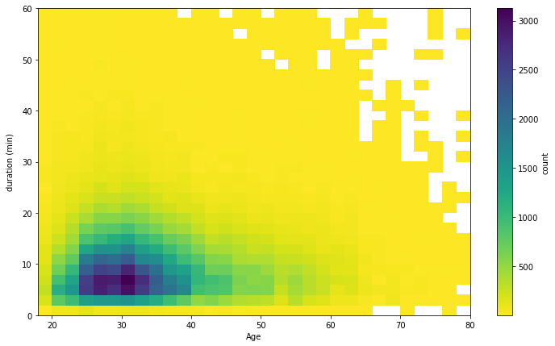

```python
# Now, let's see the duration associated with the most frequent age using a heat map:

plt.figure(figsize=[12,7])

x_bins = np.arange(fordgobike.age.min(), fordgobike.age.max()+2, 2)
y_bins = np.arange(0, 100, 2)
plt.hist2d(data=fordgobike, x='age', y='duration_min', cmin=0.5, cmap='viridis_r', bins=[x_bins, y_bins])
plt.colorbar(label='count')
plt.ylim(0,60);
plt.xlabel('Age')
plt.ylabel('duration (min)', labelpad=10);
```

The duration associated with the most frequent age, ranging from 20 to 45 years old, is 20 minutes or less. This is normal because most people, in general, do not ride bikes for an hour or more since it will be exhausting, specially if it is frequent or daily.

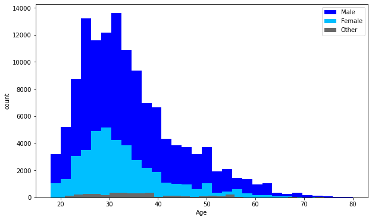

```python
# age distribution for different genders:

plt.figure(figsize=[10,6])
plt.hist(fordgobike[fordgobike.member_gender == 'Male'].age, bins=30, color='blue');
plt.hist(fordgobike[fordgobike.member_gender == 'Female'].age, bins=30, color='deepskyblue');
plt.hist(fordgobike[fordgobike.member_gender == 'Other'].age, bins=30, color='DimGray')
plt.legend(['Male','Female','Other']);
plt.xlabel('Age')
plt.ylabel('count');
```

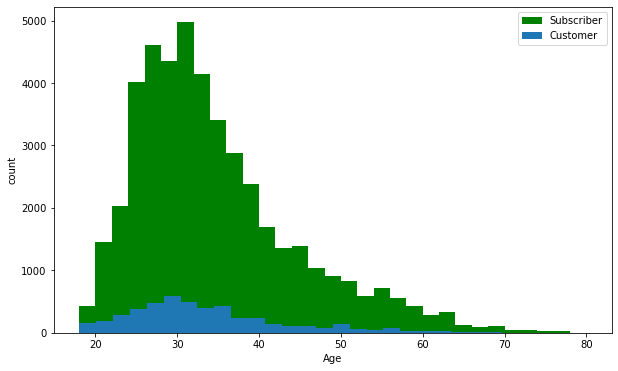

```python
# age distribution for different users:
plt.figure(figsize=[10,6])
plt.hist(ford_samp[ford_samp.user_type == 'Subscriber'].age, bins=30, color='green');
plt.hist(ford_samp[ford_samp.user_type == 'Customer'].age, bins=30);
plt.legend(['Subscriber','Customer']);
plt.xlabel('Age')
plt.ylabel('count');
```

There is a peak age for subscribers few years above 30, while the peak for customers is about 30.

### Talk about some of the relationships you observed in this part of the investigation. How did the feature(s) of interest vary with other features in the dataset?

> Most of the trips take, on average, from 4 to 11 minutes. The mean duration is nearly steady, of about 11 minutes, through week days. However, the average duration for weekends is a little bit longer. There is a positive weak correlation between age and tip duration, with the duration associated with the most frequent age is 20 minutes or less.

### Did you observe any interesting relationships between the other features (not the main feature(s) of interest)?

> No, in fact all the relations seemed consistent.

## Multivariate Exploration

##### Questions I will be answering:

```
1- Does the average trip duration associated with different days and hours differ by user type?
2- is the duration, associated with the most frequent age, the same for both genders?
3- Does average duration for each gender differ by user_type?
```

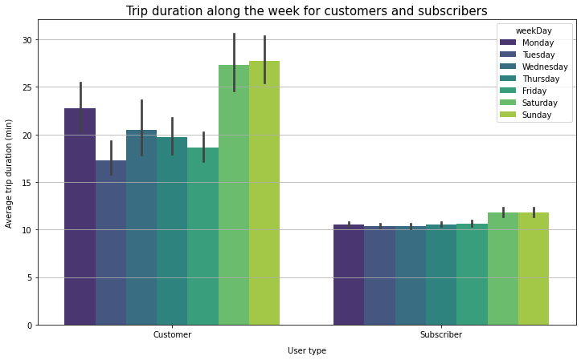

```python
# 1- Does the average trip duration associated with different days and hours differ by user type?

plt.figure(figsize=[12,7])
sb.barplot(data=fordgobike, x='user_type', y='duration_min', hue='weekDay', palette='viridis')
plt.grid(axis='y')
plt.title('Trip duration along the week for customers and subscribers', fontsize= 15)
plt.ylabel('Average trip duration (min)', labelpad=10)
plt.xlabel('User type', labelpad=10);
```

So, obviously Customers' trips take more time in general. The interesting thing here is the steady average trip time around the week for the Sbscribers versus the vriability in the duration for the Customers. This is actually predictable since subscribers are expected to maintain a fixed use, while customers are free of that commitment.

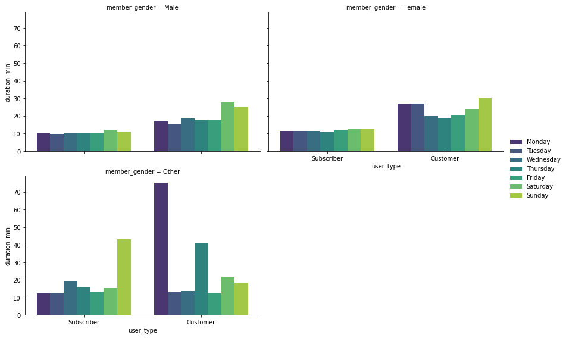

```python
# Now I will create the above plot for different genders:

g = sb.FacetGrid(data=ford_samp, col='member_gender', col_wrap=2, height=4, aspect=1.5)
g.map(sb.barplot, 'user_type', 'duration_min', 'weekDay', order=user_order, palette='viridis', ci=0)
g.add_legend();
```

Here is an interesting thing in the second plot. As compared to the first plot, we can see that females' trips takes longer durations on average. Also, the subscribers from both genders maintain an average duration, though there is variability for Other gender durations.

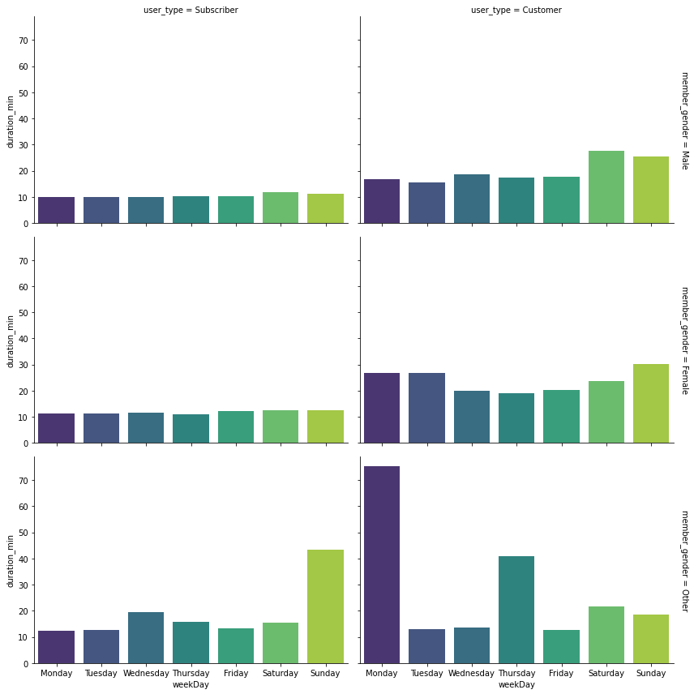

```python
# The same plot as the above.
user_order = ['Subscriber', 'Customer']
gender_order = ['Male', 'Female', 'Other']
g = sb.FacetGrid(data=ford_samp, col='user_type', col_order=user_order, row='member_gender', row_order=gender_order, height=4, aspect=1.5, margin_titles=True)
g.map(sb.barplot, 'weekDay', 'duration_min', palette='viridis', ci=0);
```

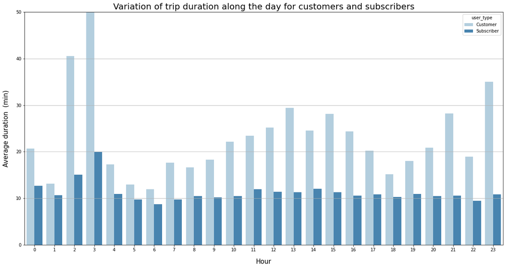

```python
# Now I will see the variation of the mean duration along the day for both customers and subscribers:

plt.figure(figsize=[20,10])
sb.barplot(data=fordgobike, x='start_hour', y='duration_min', hue='user_type', palette='Blues', ci=0)
plt.grid(axis='y')
plt.ylim(0,50)
plt.title('Variation of trip duration along the day for customers and subscribers', fontsize= 20)
plt.xlabel('Hour', fontsize= 15, labelpad=15)
plt.ylabel('Average duration  (min)', fontsize= 15, labelpad=15);
```

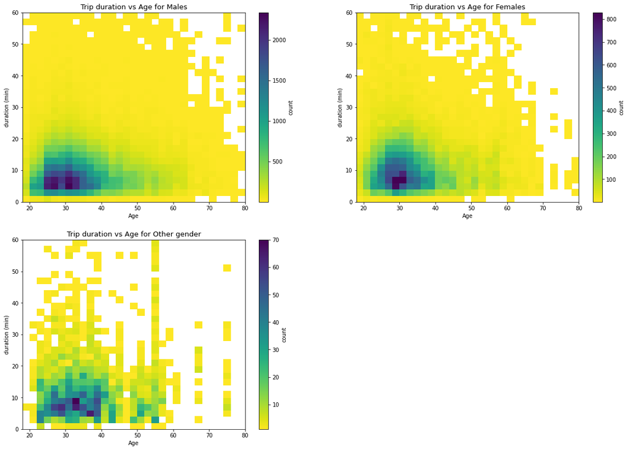

```python
# 2- is the duration, associated with the most frequent age, the same for both genders?


plt.figure(figsize=[20,14])
x_bins = np.arange(fordgobike.age.min(), fordgobike.age.max()+2, 2)
y_bins = np.arange(0, 100, 2)

plt.subplot(2,2,1)
plt.hist2d(data=fordgobike[fordgobike.member_gender == 'Male'], x='age', y='duration_min', cmin=0.5, cmap='viridis_r', bins=[x_bins, y_bins])
plt.colorbar(label='count')
plt.ylim(0,60)
plt.title('Trip duration vs Age for Males', fontsize= 13)
plt.xlabel('Age')
plt.ylabel('duration (min)');

plt.subplot(2,2,2)
plt.hist2d(data=fordgobike[fordgobike.member_gender == 'Female'], x='age', y='duration_min', cmin=0.5, cmap='viridis_r', bins=[x_bins, y_bins])
plt.colorbar(label='count')
plt.ylim(0,60)
plt.title('Trip duration vs Age for Females', fontsize= 13)
plt.xlabel('Age')
plt.ylabel('duration (min)');

plt.subplot(2,2,3)
plt.hist2d(data=fordgobike[fordgobike.member_gender == 'Other'], x='age', y='duration_min', cmin=0.5, cmap='viridis_r', bins=[x_bins, y_bins])
plt.colorbar(label='count')
plt.ylim(0,60)
plt.title('Trip duration vs Age for Other gender', fontsize= 13)
plt.xlabel('Age')
plt.ylabel('duration (min)');
```

Almost no difference. The time range associated with the most frequent age for each category is the same. However, we notice that male age is more braoden for that range than female age. Other gender age looks bimodal between 30 and 40.

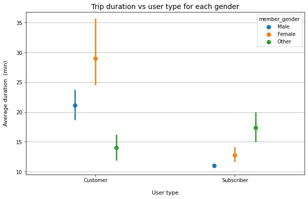

```python
# 3- Does average duration for each user_type differ by gender?

plt.figure(figsize=[10,6])
sb.pointplot(data=fordgobike.query('age > 25 and age > 45'), x='user_type', y='duration_min', hue='member_gender',
             linestyles="", dodge=.3, hue_order=gender_order)
plt.grid(axis='y')
plt.title('Trip duration vs user type for each gender', fontsize= 14)
plt.xlabel('User type', fontsize= 11, labelpad=15)
plt.ylabel('Average duration  (min)', fontsize= 11, labelpad=15);
```

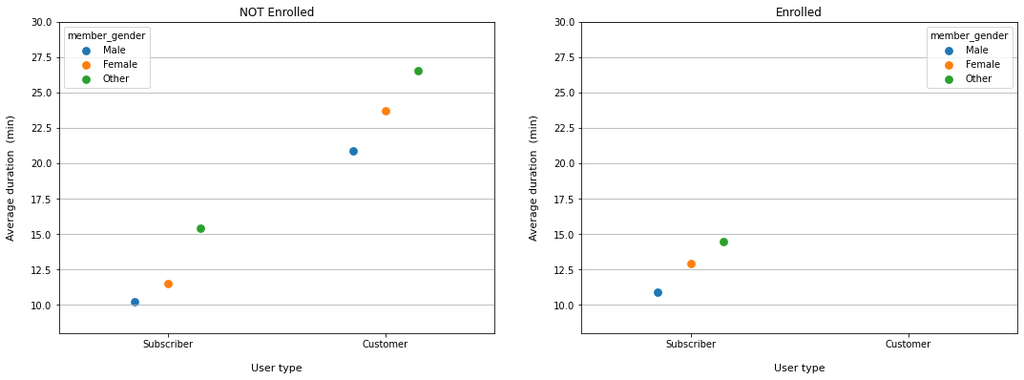

```python
# the effect of bike_share_for_all program on the duration for each user type and gender:

plt.figure(figsize=[18, 6])

plt.subplot(1,2,1)
sb.pointplot(data=fordgobike[fordgobike.bike_share_for_all_trip == 'No'], x='user_type', y='duration_min',
             hue='member_gender', linestyles="", ci=0, dodge=.3, order=user_order, hue_order=gender_order)
plt.grid(axis='y')
plt.ylim(8,30)
plt.title('NOT Enrolled')
plt.xlabel('User type', fontsize= 11, labelpad=15)
plt.ylabel('Average duration  (min)', fontsize= 11, labelpad=15);

plt.subplot(1,2,2)
sb.pointplot(data=fordgobike[fordgobike.bike_share_for_all_trip == 'Yes'], x='user_type', y='duration_min',
             hue='member_gender', linestyles="", ci=0, dodge=.3, order=user_order, hue_order=gender_order)
plt.grid(axis='y');
plt.ylim(8,30)
plt.title('Enrolled')
plt.xlabel('User type', fontsize= 11, labelpad=15)
plt.ylabel('Average duration  (min)', fontsize= 11, labelpad=15);
```

The plot to the right reflects the fact that Customers are not part of bike_share_for_all_trip program, since they are not subscribers in the first place.